# Generating SQL for SQLite using Ollama, ChromaDB

This notebook runs through the process of using the `vanna` Python package to generate SQL using AI (RAG + LLMs) including connecting to a database and training. If you're not ready to train on your own database, you can still try it using a sample SQLite database.

### Which LLM do you want to use?

- OpenAI via Vanna.AI (Recommended)

  Use Vanna.AI for free to generate your queries
- OpenAI

  Use OpenAI with your own API key
- Azure OpenAI

  If you have OpenAI models deployed on Azure
- Ollama

  Use Ollama locally for free. Requires additional setup.
- Mistral via Mistral API

  If you have a Mistral API key
- Other LLM

  If you have a different LLM model

### Where do you want to store the 'training' data?

- Vanna Hosted Vector DB (Recommended)

  Use Vanna.AIs hosted vector database (pgvector) for free. This is usable across machines with no additional setup.
- ChromaDB

  Use ChromaDBs open-source vector database for free locally. No additional setup is necessary -- all database files will be created and stored locally.
- Marqo

  Use Marqo locally for free. Requires additional setup. Or use their hosted option.
- Other VectorDB

  Use any other vector database. Requires additional setup.

## Setup

```python
from vanna.ollama import Ollama
from vanna.chromadb.chromadb_vector import ChromaDB_VectorStore
```

```python
class MyVanna(ChromaDB_VectorStore, Ollama):
    def __init__(self, config=None):
        ChromaDB_VectorStore.__init__(self, config=config)
        Ollama.__init__(self, config=config)

config = {
    'model': 'llama3'  # 'mistral' # "starcoder2"
}
vn = MyVanna(config=config)
```

### Which database do you want to query?

- Postgres
- Microsoft SQL Server
- DuckDB
- Snowflake
- BigQuery
- SQLite
- Other Database

  Use Vanna to generate queries for any SQL database

```python
import os.path
import re
from time import time
```

```python
# file_db = "./db/gpt3sql.sqlite"

file_db = "~/Downloads/chinook.sqlite"
file_db = os.path.abspath(os.path.expanduser(file_db))
vn.connect_to_sqlite(file_db)
```

```python
vn.run_sql_is_set
```

```
True
```

```python
def remove_collections(collection_name=None, ACCEPTED_TYPES = ["sql", "ddl", "documentation"]):
    if not collection_name:
        collections = ACCEPTED_TYPES
    elif isinstance(collection_name, str):
        collections = [collection_name]
    elif isinstance(collection_name, list):
        collections = collection_name
    else:
        print(f"\t{collection_name} is unknown: Skipped")
        return

    for c in collections:
        if not c in ACCEPTED_TYPES:
            print(f"\t{c} is unknown: Skipped")
            continue

        # print(f"vn.remove_collection('{c}')")
        vn.remove_collection(c)
```

```python
def strip_brackets(ddl):
    """
    This function removes square brackets from table and column names in a DDL script.

    Args:
        ddl (str): The DDL script containing square brackets.

    Returns:
        str: The DDL script with square brackets removed.
    """
    # Use regular expressions to match and replace square brackets
    pattern = r"\[([^\]]+)]"  # Match any character except ] within square brackets
    return re.sub(pattern, r"\1", ddl)
```

```python
if False:
    remove_collections()
```

## Training

You only need to train once. Do not train again unless you want to add more training data.

```python
# show training data
training_data = vn.get_training_data()
training_data
```

|  | id | question | content | training_data_type |
| --- | --- | --- | --- | --- |
| 0 | 5698caa9-f558-5bc3-ab17-53fdf8d8e27a-sql | what are the top 5 countries that customers co... | SELECT Country, COUNT(*) AS TotalCustomers\nFR... | sql |
| 1 | ad7073e4-6bfb-593d-802a-8b0d388fafa4-sql | How many records are in table called customer | SELECT COUNT(*) FROM Customer | sql |
| 2 | c9165031-db41-5792-8000-bd3db552c193-sql | Show me a list of tables in the SQLite database | SELECT name FROM sqlite_master WHERE type='table' | sql |
| 3 | e676785b-a05d-541a-bcf4-52eda4106c03-sql | What person has a name of "John Doe"? | SELECT * FROM t_person WHERE name = 'John Doe' | sql |
| 0 | 00e3136b-f688-5ae4-a2bb-3354635261fc-ddl | None | CREATE INDEX IFK_CustomerSupportRepId ON Custo... | ddl |
| 1 | 04a3d9eb-fab7-5641-96a1-ae7924ae05e5-ddl | None | CREATE INDEX IFK_EmployeeReportsTo ON Employee... | ddl |
| 2 | 11439f95-bfbc-530c-8b7f-91f9e45d2877-ddl | None | CREATE TABLE Track\n(\n TrackId INTEGER NO... | ddl |
| 3 | 29f57d6d-552a-5cc2-8c8c-cb78918d1646-ddl | None | CREATE TABLE Genre\n(\n GenreId INTEGER NO... | ddl |
| 4 | 33d9efb0-969c-59b8-95f1-04b3e0ddd2df-ddl | None | CREATE INDEX IFK_TrackAlbumId ON Track (AlbumId) | ddl |
| 5 | 37bc3b25-2dc1-5160-bcae-baf85b93f023-ddl | None | CREATE TABLE InvoiceLine\n(\n InvoiceLineId... | ddl |
| 6 | 4893f9e4-2275-53cb-89da-43de3063acf1-ddl | None | CREATE TABLE PlaylistTrack\n(\n PlaylistId ... | ddl |
| 7 | 82dfbbaf-4fe6-5213-8c5a-2e765f459ca1-ddl | None | CREATE TABLE Artist\n(\n ArtistId INTEGER ... | ddl |
| 8 | 8a3cbf5f-a4d9-5429-93de-e49ef72c5bd5-ddl | None | CREATE TABLE Customer\n(\n CustomerId INTEG... | ddl |
| 9 | 93344862-5b4e-5a02-8c70-982b08c6badf-ddl | None | CREATE INDEX IFK_InvoiceLineInvoiceId ON Invoi... | ddl |
| 10 | 96df68d6-cba8-5982-9b6e-4dd4e797683f-ddl | None | CREATE INDEX IFK_AlbumArtistId ON Album (Artis... | ddl |
| 11 | 97594156-2183-5f7b-82f6-a6ae2d3e248c-ddl | None | CREATE INDEX IFK_InvoiceLineTrackId ON Invoice... | ddl |
| 12 | 9f818206-3266-527b-8906-e9644c2414f4-ddl | None | CREATE TABLE Employee\n(\n EmployeeId INTEG... | ddl |
| 13 | a4e8be30-d5dd-5a8a-aa99-64c74783e17d-ddl | None | \n CREATE TABLE IF NOT EXISTS t_person (\n ... | ddl |
| 14 | b586614d-f6de-5d5e-aa55-692d9fbbc325-ddl | None | CREATE TABLE Playlist\n(\n PlaylistId INTEG... | ddl |
| 15 | b5cb3609-158b-57bb-9124-1425c39eb7d6-ddl | None | CREATE INDEX IFK_TrackGenreId ON Track (GenreId) | ddl |
| 16 | bf1f06a1-8065-512c-bfe7-591d0e017d3e-ddl | None | CREATE TABLE Invoice\n(\n InvoiceId INTEGER... | ddl |
| 17 | c88034a5-9a78-5b9b-b864-d9b542ffff77-ddl | None | CREATE TABLE MediaType\n(\n MediaTypeId INT... | ddl |
| 18 | ca1e33d8-8948-52fa-8c3d-0b5f6b0cccdc-ddl | None | CREATE INDEX IFK_TrackMediaTypeId ON Track (Me... | ddl |
| 19 | cfe3064c-0442-5555-be9c-bbc8fa9542a8-ddl | None | CREATE INDEX IFK_InvoiceCustomerId ON Invoice ... | ddl |
| 20 | e9124f31-fca1-5503-b473-9b995624b92e-ddl | None | CREATE TABLE Album\n(\n AlbumId INTEGER NO... | ddl |
| 21 | f4b619e3-ec27-5093-a24f-938a38bd48a2-ddl | None | CREATE INDEX IFK_PlaylistTrackTrackId ON Playl... | ddl |
| 0 | 51cf1d6d-7637-5b87-b9e7-31c577fbde59-doc | None | Our business defines OTIF score as the percent... | documentation |

## Asking the AI

Whenever you ask a new question, it will find the 10 most relevant pieces of training data and use it as part of the LLM prompt to generate the SQL.

```python
ts_start = time()
```

```
Number of requested results 10 is greater than number of elements in index 4, updating n_results = 4
Number of requested results 10 is greater than number of elements in index 1, updating n_results = 1
```

[output not shown]

```
Add of existing embedding ID: c9165031-db41-5792-8000-bd3db552c193-sql
Insert of existing embedding ID: c9165031-db41-5792-8000-bd3db552c193-sql
```

[output not shown]

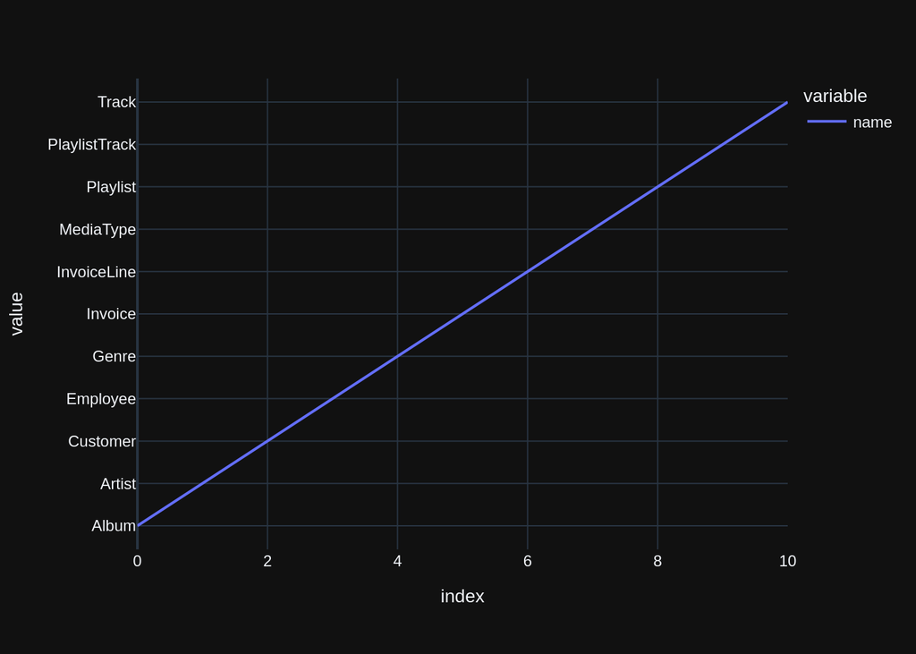

```
("SELECT name FROM sqlite_master WHERE type='table'",
              name
 0           Album
 1          Artist
 2        Customer
 3        Employee
 4           Genre
 5         Invoice
 6     InvoiceLine
 7       MediaType
 8        Playlist
 9   PlaylistTrack
 10          Track,
 Figure({
     'data': [{'hovertemplate': 'variable=name<br>index=%{x}<br>value=%{y}<extra></extra>',
               'legendgroup': 'name',
               'line': {'color': '#636efa', 'dash': 'solid'},
               'marker': {'symbol': 'circle'},
               'mode': 'lines',
               'name': 'name',
               'orientation': 'v',
               'showlegend': True,
               'type': 'scatter',
               'x': array([ 0,  1,  2,  3,  4,  5,  6,  7,  8,  9, 10]),
               'xaxis': 'x',
               'y': array(['Album', 'Artist', 'Customer', 'Employee', 'Genre', 'Invoice',
                           'InvoiceLine', 'MediaType', 'Playlist', 'PlaylistTrack', 'Track'],
                          dtype=object),
               'yaxis': 'y'}],
     'layout': {'legend': {'title': {'text': 'variable'}, 'tracegroupgap': 0},
                'margin': {'t': 60},
                'template': '...',
                'xaxis': {'anchor': 'y', 'domain': [0.0, 1.0], 'title': {'text': 'index'}},
                'yaxis': {'anchor': 'x', 'domain': [0.0, 1.0], 'title': {'text': 'value'}}}
 }))
```

```python
vn.ask(question="Show me a list of tables in the SQLite database")
```

```
Number of requested results 10 is greater than number of elements in index 4, updating n_results = 4
Number of requested results 10 is greater than number of elements in index 1, updating n_results = 1
```

[output not shown]

```
Add of existing embedding ID: ad7073e4-6bfb-593d-802a-8b0d388fafa4-sql
Insert of existing embedding ID: ad7073e4-6bfb-593d-802a-8b0d388fafa4-sql
```

[output not shown]

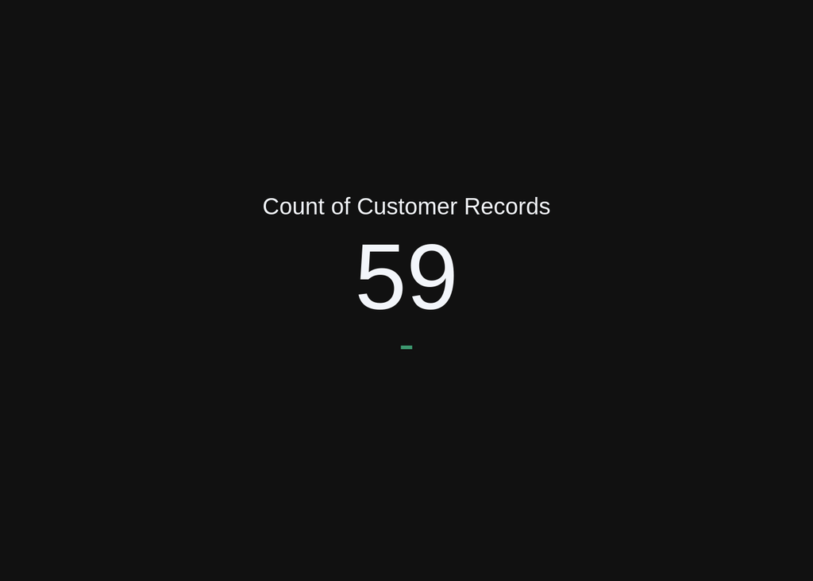

```
('SELECT COUNT(*) FROM Customer',
    COUNT(*)
 0        59,
 Figure({
     'data': [{'mode': 'number+delta', 'title': {'text': 'Count of Customer Records'}, 'type': 'indicator', 'value': 59}],
     'layout': {'template': '...'}
 }))
```

```python
vn.ask(question="How many records are in table called customer")
```

```
Number of requested results 10 is greater than number of elements in index 4, updating n_results = 4
Number of requested results 10 is greater than number of elements in index 1, updating n_results = 1
```

[output not shown]

```
Add of existing embedding ID: 5698caa9-f558-5bc3-ab17-53fdf8d8e27a-sql
Insert of existing embedding ID: 5698caa9-f558-5bc3-ab17-53fdf8d8e27a-sql
```

[output not shown]

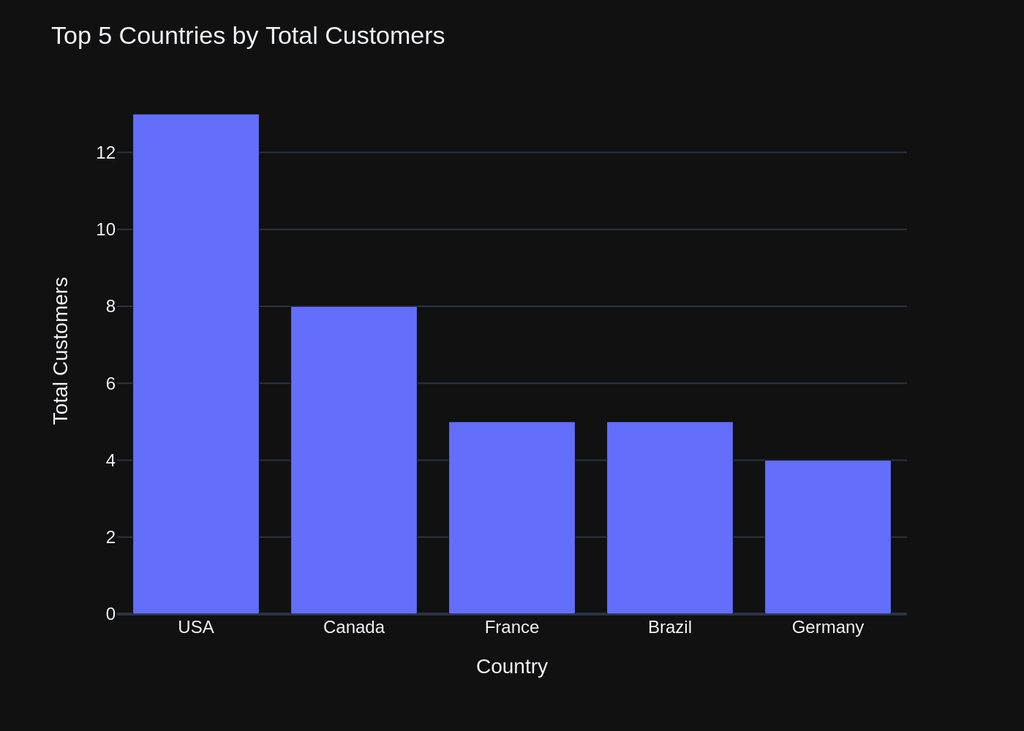

```
('SELECT Country, COUNT(*) AS TotalCustomers\nFROM Customer\nGROUP BY Country\nORDER BY TotalCustomers DESC\nLIMIT 5',
    Country  TotalCustomers
 0      USA              13
 1   Canada               8
 2   France               5
 3   Brazil               5
 4  Germany               4,
 Figure({
     'data': [{'alignmentgroup': 'True',
               'hovertemplate': 'Country=%{x}<br>TotalCustomers=%{y}<extra></extra>',
               'legendgroup': '',
               'marker': {'color': '#636efa', 'pattern': {'shape': ''}},
               'name': '',
               'offsetgroup': '',
               'orientation': 'v',
               'showlegend': False,
               'textposition': 'auto',
               'type': 'bar',
               'x': array(['USA', 'Canada', 'France', 'Brazil', 'Germany'], dtype=object),
               'xaxis': 'x',
               'y': array([13,  8,  5,  5,  4]),
               'yaxis': 'y'}],
     'layout': {'barmode': 'relative',
                'legend': {'tracegroupgap': 0},
                'margin': {'t': 60},
                'template': '...',
                'title': {'text': 'Top 5 Countries by Total Customers'},
                'xaxis': {'anchor': 'y', 'domain': [0.0, 1.0], 'title': {'text': 'Country'}},
                'yaxis': {'anchor': 'x', 'domain': [0.0, 1.0], 'title': {'text': 'Total Customers'}}}
 }))
```

```python
vn.ask(question="what are the top 5 countries that customers come from?")
```

### More SQL questions

see `sample-sql-queries-sqlite-chinook.ipynb`

```
Number of requested results 10 is greater than number of elements in index 4, updating n_results = 4
Number of requested results 10 is greater than number of elements in index 1, updating n_results = 1
```

[output not shown]

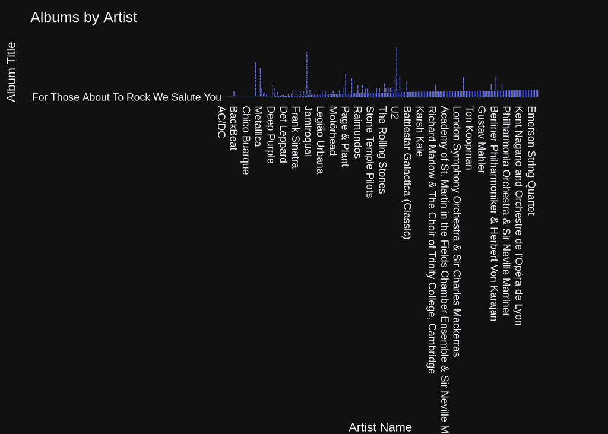

```
('SELECT a.Title, a.ArtistId, ar.Name\nFROM Album a\nJOIN Artist ar ON a.ArtistId = ar.ArtistId',
                                                  Title  ArtistId  \
 0                For Those About To Rock We Salute You         1
 1                                    Balls to the Wall         2
 2                                    Restless and Wild         2
 3                                    Let There Be Rock         1
 4                                             Big Ones         3
 ..                                                 ...       ...
 342                             Respighi:Pines of Rome       226
 343  Schubert: The Late String Quartets & String Qu...       272
 344                                Monteverdi: L'Orfeo       273
 345                              Mozart: Chamber Music       274
 346  Koyaanisqatsi (Soundtrack from the Motion Pict...       275

                                                   Name
 0                                                AC/DC
 1                                               Accept
 2                                               Accept
 3                                                AC/DC
 4                                            Aerosmith
 ..                                                 ...
 342                                     Eugene Ormandy
 343                             Emerson String Quartet
 344  C. Monteverdi, Nigel Rogers - Chiaroscuro; Lon...
 345                                      Nash Ensemble
 346                              Philip Glass Ensemble

 [347 rows x 3 columns],
 Figure({
     'data': [{'alignmentgroup': 'True',
               'hovertemplate': 'Name=%{x}<br>Title=%{y}<extra></extra>',
               'legendgroup': '',
               'marker': {'color': '#636efa', 'pattern': {'shape': ''}},
               'name': '',
               'offsetgroup': '',
               'orientation': 'v',
               'showlegend': False,
               'textposition': 'auto',
               'type': 'bar',
               'x': array(['AC/DC', 'Accept', 'Accept', ...,
                           'C. Monteverdi, Nigel Rogers - Chiaroscuro; London Baroque; London Cornett & Sackbu',
                           'Nash Ensemble', 'Philip Glass Ensemble'], dtype=object),
               'xaxis': 'x',
               'y': array(['For Those About To Rock We Salute You', 'Balls to the Wall',
                           'Restless and Wild', ..., "Monteverdi: L'Orfeo",
                           'Mozart: Chamber Music',
                           'Koyaanisqatsi (Soundtrack from the Motion Picture)'], dtype=object),
               'yaxis': 'y'}],
     'layout': {'barmode': 'relative',
                'legend': {'tracegroupgap': 0},
                'margin': {'t': 60},
                'template': '...',
                'title': {'text': 'Albums by Artist'},
                'xaxis': {'anchor': 'y', 'domain': [0.0, 1.0], 'title': {'text': 'Artist Name'}},
                'yaxis': {'anchor': 'x', 'domain': [0.0, 1.0], 'title': {'text': 'Album Title'}}}
 }))
```

```python
question = """
    List all albums and their corresponding artist names
"""

vn.ask(question=question)
```

```
Number of requested results 10 is greater than number of elements in index 5, updating n_results = 5
Number of requested results 10 is greater than number of elements in index 1, updating n_results = 1
```

[output not shown]

[output cut: 45 more lines]

````
15        221387    7251478       0.99
16       2610250  484583988       1.99
17       2616410  183867185       1.99
18        353567   11542247       0.99
19        280764    9306737       0.99
20        215084    3499018       0.99
21        209573    3426106       0.99
Ollama parameters:
model=llama3:latest,
options={},
keep_alive=None
Prompt Content:
[{"role": "system", "content": "The following is a pandas DataFrame that contains the results of the query that answers the question the user asked: '  \n    Find all tracks with a name containing \"What\" (case-insensitive)\n'\n\nThe DataFrame was produced using this query: SELECT * \nFROM Track \n…
Ollama Response:
{'model': 'llama3:latest', 'created_at': '2024-06-08T23:25:32.497452247Z', 'message': {'role': 'assistant', 'content': '```\nimport plotly.express as px\nimport plotly.graph_objects as go\n\nfig = px.bar(df, x="Name", y="Milliseconds")\nfig.update_layout(title=\'What tracks duration\')\nfig.show()\n…
````

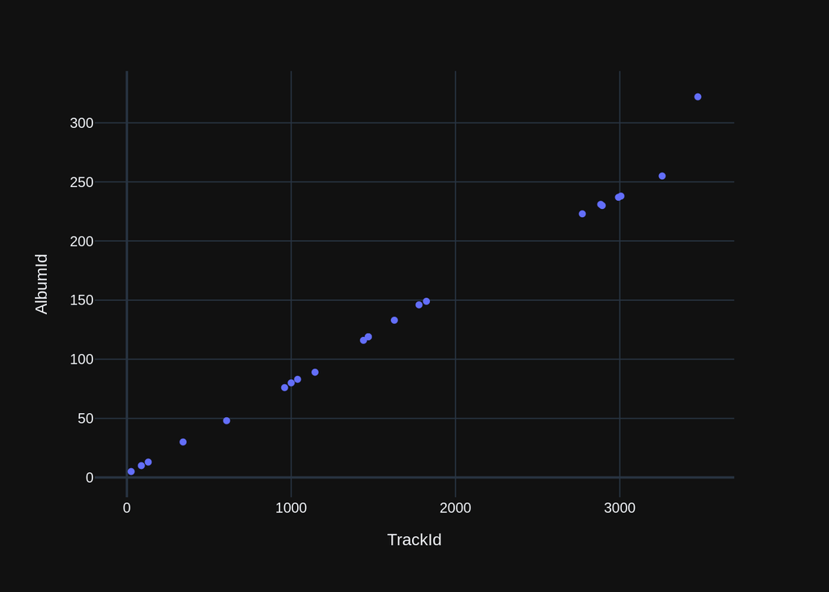

```
("SELECT * \nFROM Track \nWHERE LOWER(Name) LIKE '%what%'",
     TrackId                                          Name  AlbumId  \
 0        26                                 What It Takes        5
 1        88                                  What You Are       10
 2       130                             Do what cha wanna       13
 3       342                   What is and Should Never Be       30
 4       607                                       So What       48
 5       960                                    What A Day       76
 6      1000                                 What If I Do?       80
 7      1039                              What Now My Love       83
 8      1145                                   Whatsername       89
 9      1440             Whatever It Is, I Just Can't Stop      116
 10     1469                         Look What You've Done      119
 11     1470                             Get What You Need      119
 12     1628              What Is And What Should Never Be      133
```

[output cut: 78 more lines]

```python
question = """
    Find all tracks with a name containing "What" (case-insensitive)
"""

vn.ask(question=question)
```

```
Number of requested results 10 is greater than number of elements in index 6, updating n_results = 6
Number of requested results 10 is greater than number of elements in index 1, updating n_results = 1
```

[output not shown]

[output cut: 68 more lines]

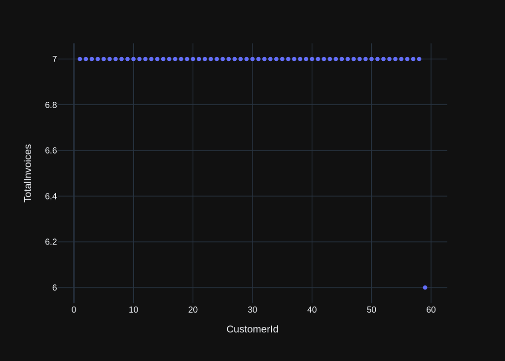

```
('SELECT CustomerId, COUNT(*) AS TotalInvoices\nFROM Invoice\nGROUP BY CustomerId',
     CustomerId  TotalInvoices
 0            1              7
 1            2              7
 2            3              7
 3            4              7
 4            5              7
 5            6              7
 6            7              7
 7            8              7
 8            9              7
 9           10              7
 10          11              7
 11          12              7
 12          13              7
```

[output cut: 70 more lines]

```python
question = """
    Get the total number of invoices for each customer
"""

vn.ask(question=question)
```

```
Number of requested results 10 is greater than number of elements in index 7, updating n_results = 7
Number of requested results 10 is greater than number of elements in index 1, updating n_results = 1
```

[output not shown]

[output cut: 11 more lines]

````
17         Finland              7
18         Denmark              7
19           Chile              7
20         Belgium              7
21         Austria              7
22       Australia              7
23       Argentina              7
Ollama parameters:
model=llama3:latest,
options={},
keep_alive=None
Prompt Content:
[{"role": "system", "content": "The following is a pandas DataFrame that contains the results of the query that answers the question the user asked: '  \n    Find the total number of invoices per country:\n'\n\nThe DataFrame was produced using this query: SELECT c.Country, COUNT(i.InvoiceId) AS Tota…
Ollama Response:
{'model': 'llama3:latest', 'created_at': '2024-06-08T23:29:14.18934331Z', 'message': {'role': 'assistant', 'content': "```\nimport plotly.express as px\nimport numpy as np\n\nfig = px.bar(df, x='Country', y='TotalInvoices', title='Total Number of Invoices per Country')\n\nfig.update_layout(xaxis_tit…
````

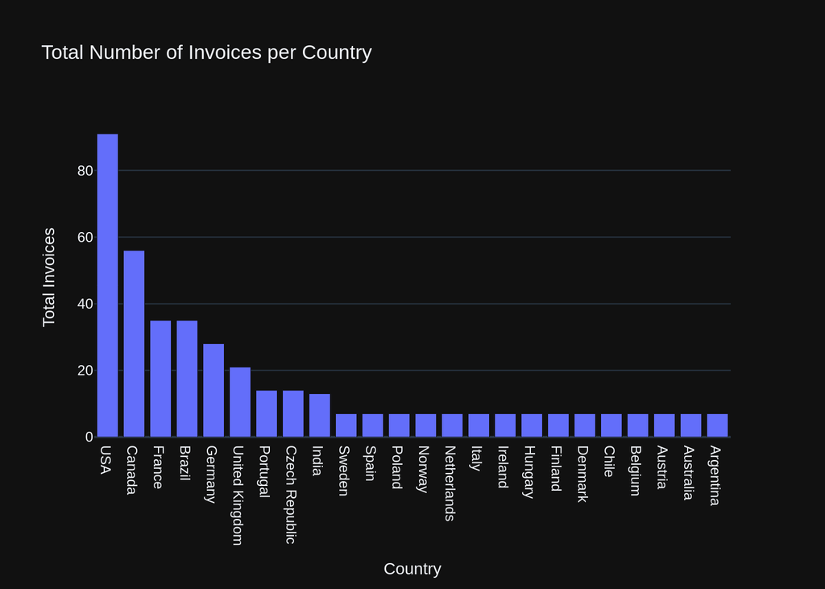

```
('SELECT c.Country, COUNT(i.InvoiceId) AS TotalInvoices\nFROM Customer c\nJOIN Invoice i ON c.CustomerId = i.CustomerId\nGROUP BY c.Country\nORDER BY TotalInvoices DESC',
            Country  TotalInvoices
 0              USA             91
 1           Canada             56
 2           France             35
 3           Brazil             35
 4          Germany             28
 5   United Kingdom             21
 6         Portugal             14
 7   Czech Republic             14
 8            India             13
 9           Sweden              7
 10           Spain              7
 11          Poland              7
 12          Norway              7
 13     Netherlands              7
 14           Italy              7
 15         Ireland              7
 16         Hungary              7
 17         Finland              7
 18         Denmark              7
 19           Chile              7
 20         Belgium              7
 21         Austria              7
 22       Australia              7
 23       Argentina              7,
 Figure({
     'data': [{'alignmentgroup': 'True',
               'hovertemplate': 'Country=%{x}<br>TotalInvoices=%{y}<extra></extra>',
               'legendgroup': '',
               'marker': {'color': '#636efa', 'pattern': {'shape': ''}},
               'name': '',
               'offsetgroup': '',
               'orientation': 'v',
               'showlegend': False,
               'textposition': 'auto',
               'type': 'bar',
               'x': array(['USA', 'Canada', 'France', 'Brazil', 'Germany', 'United Kingdom',
                           'Portugal', 'Czech Republic', 'India', 'Sweden', 'Spain', 'Poland',
                           'Norway', 'Netherlands', 'Italy', 'Ireland', 'Hungary', 'Finland',
                           'Denmark', 'Chile', 'Belgium', 'Austria', 'Australia', 'Argentina'],
                          dtype=object),
               'xaxis': 'x',
               'y': array([91, 56, 35, 35, 28, 21, 14, 14, 13,  7,  7,  7,  7,  7,  7,  7,  7,  7,
                            7,  7,  7,  7,  7,  7]),
               'yaxis': 'y'}],
     'layout': {'barmode': 'relative',
                'legend': {'title': {'text': 'Legend'}, 'tracegroupgap': 0},
                'template': '...',
                'title': {'text': 'Total Number of Invoices per Country'},
                'xaxis': {'anchor': 'y', 'domain': [0.0, 1.0], 'title': {'text': 'Country'}},
                'yaxis': {'anchor': 'x', 'domain': [0.0, 1.0], 'title': {'text': 'Total Invoices'}}}
 }))
```

```python
question = """
    Find the total number of invoices per country:
"""

vn.ask(question=question)
```

```
Number of requested results 10 is greater than number of elements in index 8, updating n_results = 8
Number of requested results 10 is greater than number of elements in index 1, updating n_results = 1
```

[output not shown]

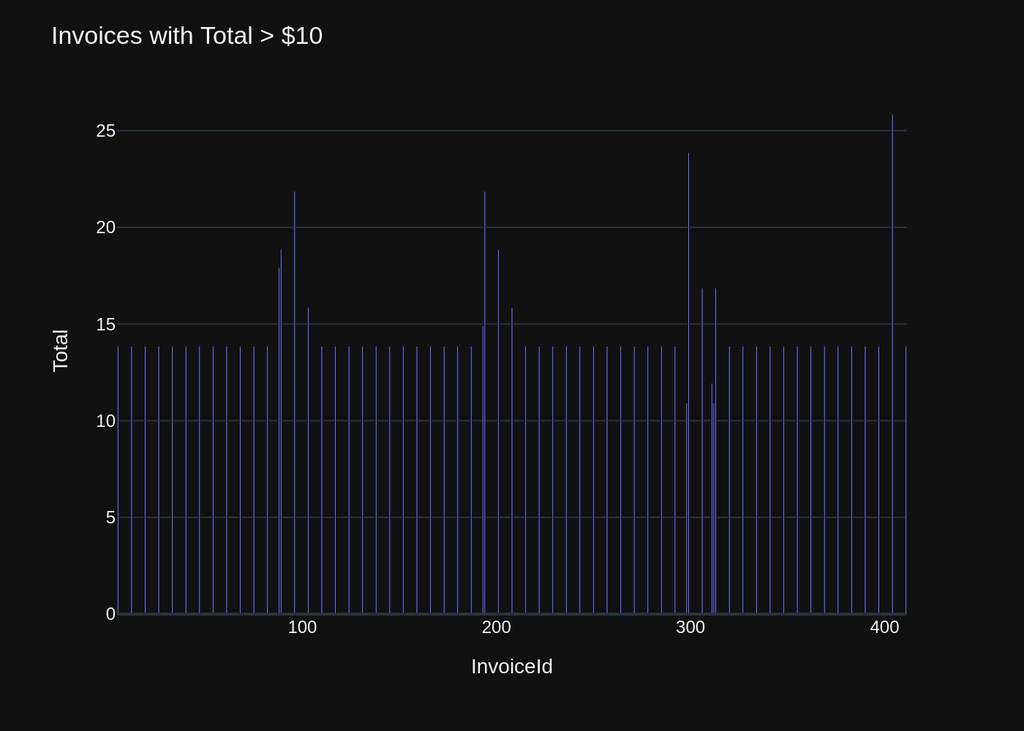

```
('SELECT * \nFROM Invoice \nWHERE Total > 10.00\n',
     InvoiceId  CustomerId          InvoiceDate             BillingAddress  \
 0           5          23  2009-01-11 00:00:00            69 Salem Street
 1          12           2  2009-02-11 00:00:00    Theodor-Heuss-Straße 34
 2          19          40  2009-03-14 00:00:00             8, Rue Hanovre
 3          26          19  2009-04-14 00:00:00            1 Infinite Loop
 4          33          57  2009-05-15 00:00:00            Calle Lira, 198
 ..        ...         ...                  ...                        ...
 59        383          10  2013-08-12 00:00:00  Rua Dr. Falcão Filho, 155
 60        390          48  2013-09-12 00:00:00      Lijnbaansgracht 120bg
 61        397          27  2013-10-13 00:00:00            1033 N Park Ave
 62        404           6  2013-11-13 00:00:00              Rilská 3174/6
 63        411          44  2013-12-14 00:00:00            Porthaninkatu 9

    BillingCity BillingState  BillingCountry BillingPostalCode  Total
 0       Boston           MA             USA              2113  13.86
 1    Stuttgart         None         Germany             70174  13.86
 2        Paris         None          France             75002  13.86
 3    Cupertino           CA             USA             95014  13.86
 4     Santiago         None           Chile              None  13.86
 ..         ...          ...             ...               ...    ...
 59   São Paulo           SP          Brazil         01007-010  13.86
 60   Amsterdam           VV     Netherlands              1016  13.86
 61      Tucson           AZ             USA             85719  13.86
 62      Prague         None  Czech Republic             14300  25.86
 63    Helsinki         None         Finland             00530  13.86

 [64 rows x 9 columns],
 Figure({
     'data': [{'alignmentgroup': 'True',
               'hovertemplate': 'InvoiceId=%{x}<br>Total=%{y}<extra></extra>',
               'legendgroup': '',
               'marker': {'color': '#636efa', 'pattern': {'shape': ''}},
               'name': '',
               'offsetgroup': '',
               'orientation': 'v',
               'showlegend': False,
               'textposition': 'auto',
               'type': 'bar',
               'x': array([  5,  12,  19,  26,  33,  40,  47,  54,  61,  68,  75,  82,  88,  89,
                            96, 103, 110, 117, 124, 131, 138, 145, 152, 159, 166, 173, 180, 187,
                           193, 194, 201, 208, 215, 222, 229, 236, 243, 250, 257, 264, 271, 278,
                           285, 292, 298, 299, 306, 311, 312, 313, 320, 327, 334, 341, 348, 355,
                           362, 369, 376, 383, 390, 397, 404, 411]),
               'xaxis': 'x',
               'y': array([13.86, 13.86, 13.86, 13.86, 13.86, 13.86, 13.86, 13.86, 13.86, 13.86,
                           13.86, 13.86, 17.91, 18.86, 21.86, 15.86, 13.86, 13.86, 13.86, 13.86,
                           13.86, 13.86, 13.86, 13.86, 13.86, 13.86, 13.86, 13.86, 14.91, 21.86,
                           18.86, 15.86, 13.86, 13.86, 13.86, 13.86, 13.86, 13.86, 13.86, 13.86,
                           13.86, 13.86, 13.86, 13.86, 10.91, 23.86, 16.86, 11.94, 10.91, 16.86,
                           13.86, 13.86, 13.86, 13.86, 13.86, 13.86, 13.86, 13.86, 13.86, 13.86,
                           13.86, 13.86, 25.86, 13.86]),
               'yaxis': 'y'}],
     'layout': {'barmode': 'relative',
                'legend': {'tracegroupgap': 0},
                'margin': {'t': 60},
                'template': '...',
                'title': {'text': 'Invoices with Total > $10'},
                'xaxis': {'anchor': 'y', 'domain': [0.0, 1.0], 'title': {'text': 'InvoiceId'}},
                'yaxis': {'anchor': 'x', 'domain': [0.0, 1.0], 'title': {'text': 'Total'}}}
 }))
```

```python
question = """
    List all invoices with a total exceeding $10:
"""

vn.ask(question=question)
```

```
Number of requested results 10 is greater than number of elements in index 9, updating n_results = 9
Number of requested results 10 is greater than number of elements in index 1, updating n_results = 1
```

[output not shown]

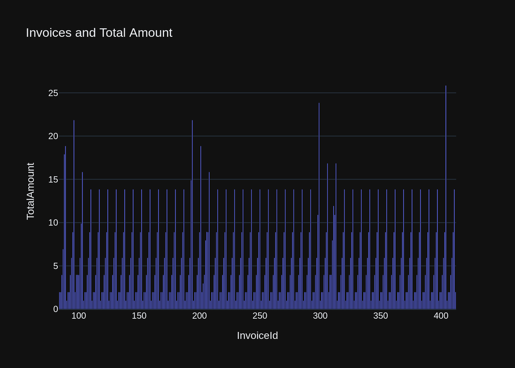

```
("SELECT InvoiceId, SUM(Total) AS TotalAmount\nFROM Invoice\nWHERE InvoiceDate >= '2010-01-01'\nGROUP BY InvoiceId",
      InvoiceId  TotalAmount
 0           84         1.98
 1           85         1.98
 2           86         3.96
 3           87         6.94
 4           88        17.91
 ..         ...          ...
 324        408         3.96
 325        409         5.94
 326        410         8.91
 327        411        13.86
 328        412         1.99

 [329 rows x 2 columns],
 Figure({
     'data': [{'alignmentgroup': 'True',
               'hovertemplate': 'InvoiceId=%{x}<br>TotalAmount=%{y}<extra></extra>',
               'legendgroup': '',
               'marker': {'color': '#636efa', 'pattern': {'shape': ''}},
               'name': '',
               'offsetgroup': '',
               'orientation': 'v',
               'showlegend': False,
               'textposition': 'auto',
               'type': 'bar',
               'x': array([ 84,  85,  86, ..., 410, 411, 412]),
               'xaxis': 'x',
               'y': array([ 1.98,  1.98,  3.96, ...,  8.91, 13.86,  1.99]),
               'yaxis': 'y'}],
     'layout': {'barmode': 'relative',
                'legend': {'tracegroupgap': 0},
                'template': '...',
                'title': {'text': 'Invoices and Total Amount'},
                'xaxis': {'anchor': 'y', 'domain': [0.0, 1.0], 'title': {'text': 'InvoiceId'}},
                'yaxis': {'anchor': 'x', 'domain': [0.0, 1.0], 'title': {'text': 'TotalAmount'}}}
 }))
```

```python
question = """
    Find all invoices since 2010 and the total amount invoiced:
"""

vn.ask(question=question)
```

```python
question = """
    List all employees and their reporting manager's name (if any):
"""

vn.ask(question=question)
```

```
Number of requested results 10 is greater than number of elements in index 1, updating n_results = 1
```

[output not shown]

[output not shown]

```
Number of requested results 10 is greater than number of elements in index 1, updating n_results = 1
```

[output not shown]

[output cut: 30 more lines]

[output not shown]

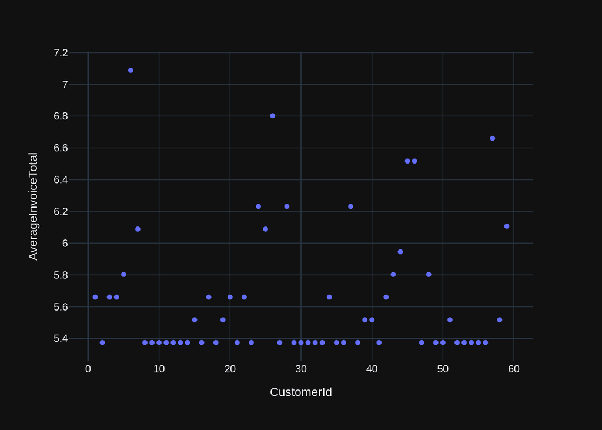

```
('SELECT c.CustomerId, AVG(i.Total) AS AverageInvoiceTotal\nFROM Customer c\nJOIN Invoice i ON c.CustomerId = i.CustomerId\nGROUP BY c.CustomerId',
     CustomerId  AverageInvoiceTotal
 0            1             5.660000
 1            2             5.374286
 2            3             5.660000
 3            4             5.660000
 4            5             5.802857
 5            6             7.088571
 6            7             6.088571
 7            8             5.374286
 8            9             5.374286
 9           10             5.374286
 10          11             5.374286
 11          12             5.374286
 12          13             5.374286
 13          14             5.374286
 14          15             5.517143
 15          16             5.374286
 16          17             5.660000
 17          18             5.374286
 18          19             5.517143
 19          20             5.660000
 20          21             5.374286
 21          22             5.660000
 22          23             5.374286
 23          24             6.231429
 24          25             6.088571
 25          26             6.802857
 26          27             5.374286
 27          28             6.231429
 28          29             5.374286
 29          30             5.374286
 30          31             5.374286
 31          32             5.374286
 32          33             5.374286
 33          34             5.660000
 34          35             5.374286
 35          36             5.374286
 36          37             6.231429
 37          38             5.374286
```

[output cut: 37 more lines]

```
                           5.37428571, 5.37428571, 5.51714286, 5.37428571, 5.66      , 5.37428571,
                           5.51714286, 5.66      , 5.37428571, 5.66      , 5.37428571, 6.23142857,
                           6.08857143, 6.80285714, 5.37428571, 6.23142857, 5.37428571, 5.37428571,
                           5.37428571, 5.37428571, 5.37428571, 5.66      , 5.37428571, 5.37428571,
                           6.23142857, 5.37428571, 5.51714286, 5.51714286, 5.37428571, 5.66      ,
                           5.80285714, 5.94571429, 6.51714286, 6.51714286, 5.37428571, 5.80285714,
                           5.37428571, 5.37428571, 5.51714286, 5.37428571, 5.37428571, 5.37428571,
                           5.37428571, 5.37428571, 6.66      , 5.51714286, 6.10666667]),
               'yaxis': 'y'}],
     'layout': {'legend': {'tracegroupgap': 0},
                'margin': {'t': 60},
                'template': '...',
                'xaxis': {'anchor': 'y', 'domain': [0.0, 1.0], 'title': {'text': 'CustomerId'}},
                'yaxis': {'anchor': 'x', 'domain': [0.0, 1.0], 'title': {'text': 'AverageInvoiceTotal'}}}
 }))
```

```python
question = """
    Get the average invoice total for each customer:
"""

vn.ask(question=question)
```

```
Number of requested results 10 is greater than number of elements in index 1, updating n_results = 1
```

[output not shown]

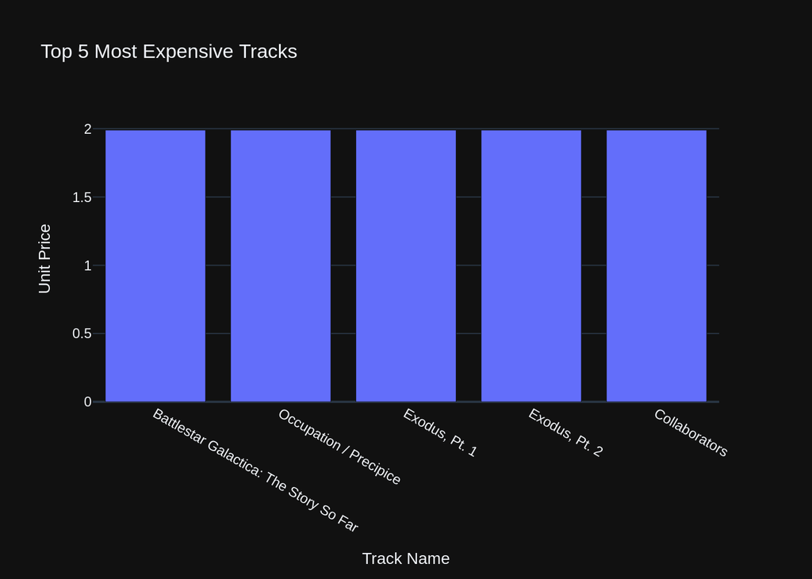

```
('SELECT t.TrackId, t.Name, t.UnitPrice\nFROM Track t\nORDER BY t.UnitPrice DESC\nLIMIT 5',
    TrackId                                    Name  UnitPrice
 0     2819  Battlestar Galactica: The Story So Far       1.99
 1     2820                  Occupation / Precipice       1.99
 2     2821                           Exodus, Pt. 1       1.99
 3     2822                           Exodus, Pt. 2       1.99
 4     2823                           Collaborators       1.99,
 Figure({
     'data': [{'type': 'bar',
               'x': array(['Battlestar Galactica: The Story So Far', 'Occupation / Precipice',
                           'Exodus, Pt. 1', 'Exodus, Pt. 2', 'Collaborators'], dtype=object),
               'y': array([1.99, 1.99, 1.99, 1.99, 1.99])}],
     'layout': {'template': '...',
                'title': {'text': 'Top 5 Most Expensive Tracks'},
                'xaxis': {'title': {'text': 'Track Name'}},
                'yaxis': {'title': {'text': 'Unit Price'}}}
 }))
```

```python
question = """
    Find the top 5 most expensive tracks (based on unit price):
"""

vn.ask(question=question)
```

```
Number of requested results 10 is greater than number of elements in index 1, updating n_results = 1
```

[output not shown]

[output cut: 12 more lines]

[output not shown]

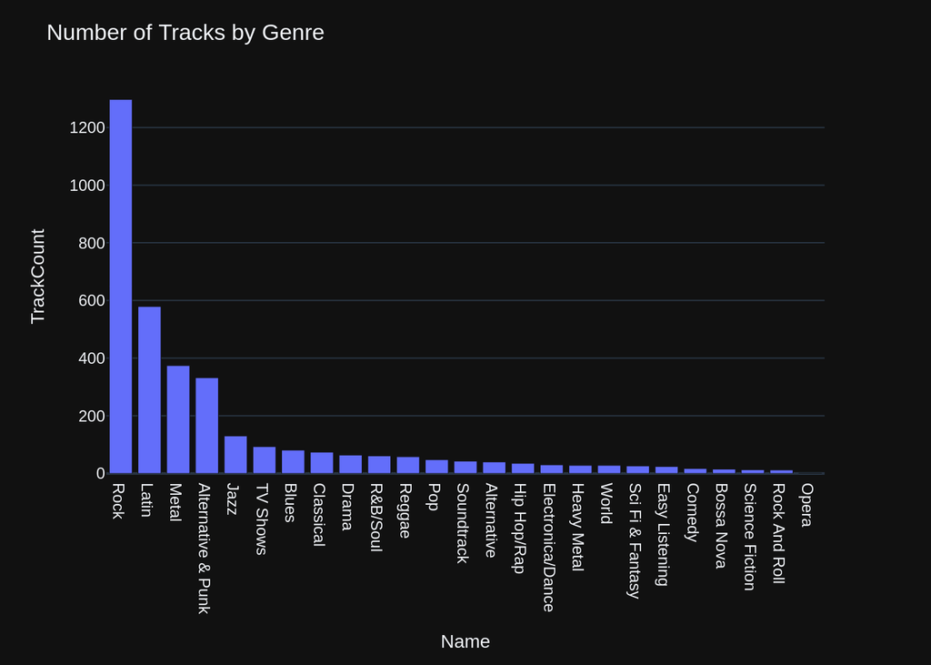

```
('SELECT g.GenreId, g.Name, COUNT(t.TrackId) AS TrackCount\nFROM Genre g\nJOIN Track t ON g.GenreId = t.GenreId\nGROUP BY g.GenreId, g.Name\nORDER BY TrackCount DESC',
     GenreId                Name  TrackCount
 0         1                Rock        1297
 1         7               Latin         579
 2         3               Metal         374
 3         4  Alternative & Punk         332
 4         2                Jazz         130
 5        19            TV Shows          93
 6         6               Blues          81
 7        24           Classical          74
 8        21               Drama          64
 9        14            R&B/Soul          61
 10        8              Reggae          58
 11        9                 Pop          48
 12       10          Soundtrack          43
 13       23         Alternative          40
 14       17         Hip Hop/Rap          35
 15       15   Electronica/Dance          30
 16       13         Heavy Metal          28
 17       16               World          28
 18       20    Sci Fi & Fantasy          26
 19       12      Easy Listening          24
 20       22              Comedy          17
 21       11          Bossa Nova          15
 22       18     Science Fiction          13
 23        5       Rock And Roll          12
 24       25               Opera           1,
 Figure({
     'data': [{'alignmentgroup': 'True',
               'hovertemplate': 'Name=%{x}<br>TrackCount=%{y}<extra></extra>',
               'legendgroup': '',
               'marker': {'color': '#636efa', 'pattern': {'shape': ''}},
               'name': '',
               'offsetgroup': '',
               'orientation': 'v',
               'showlegend': False,
               'textposition': 'auto',
               'type': 'bar',
               'x': array(['Rock', 'Latin', 'Metal', 'Alternative & Punk', 'Jazz', 'TV Shows',
                           'Blues', 'Classical', 'Drama', 'R&B/Soul', 'Reggae', 'Pop',
                           'Soundtrack', 'Alternative', 'Hip Hop/Rap', 'Electronica/Dance',
                           'Heavy Metal', 'World', 'Sci Fi & Fantasy', 'Easy Listening', 'Comedy',
                           'Bossa Nova', 'Science Fiction', 'Rock And Roll', 'Opera'], dtype=object),
               'xaxis': 'x',
               'y': array([1297,  579,  374,  332,  130,   93,   81,   74,   64,   61,   58,   48,
                             43,   40,   35,   30,   28,   28,   26,   24,   17,   15,   13,   12,
                              1]),
               'yaxis': 'y'}],
     'layout': {'barmode': 'relative',
                'legend': {'tracegroupgap': 0},
                'margin': {'t': 60},
                'template': '...',
                'title': {'text': 'Number of Tracks by Genre'},
                'xaxis': {'anchor': 'y', 'domain': [0.0, 1.0], 'title': {'text': 'Name'}},
                'yaxis': {'anchor': 'x', 'domain': [0.0, 1.0], 'title': {'text': 'TrackCount'}}}
 }))
```

```python
question = """
    List all genres and the number of tracks in each genre:
"""

vn.ask(question=question)
```

```
Number of requested results 10 is greater than number of elements in index 1, updating n_results = 1
```

[output not shown]

[figure not shown]

```
('SELECT g.GenreId, g.Name\nFROM Genre g\nWHERE NOT EXISTS (\n    SELECT 1 \n    FROM Track t \n    WHERE t.GenreId = g.GenreId\n)',
 Empty DataFrame
 Columns: [GenreId, Name]
 Index: [],
 Figure({
     'data': [{'alignmentgroup': 'True',
               'hovertemplate': 'Name=%{x}<br>count=%{y}<extra></extra>',
               'legendgroup': '',
               'marker': {'color': '#636efa', 'pattern': {'shape': ''}},
               'name': '',
               'offsetgroup': '',
               'orientation': 'v',
               'showlegend': False,
               'textposition': 'auto',
               'type': 'bar',
               'x': array([], dtype=object),
               'xaxis': 'x',
               'y': array([], dtype=int64),
               'yaxis': 'y'}],
     'layout': {'barmode': 'relative',
                'legend': {'tracegroupgap': 0},
                'margin': {'t': 60},
                'template': '...',
                'title': {'text': 'Genres Without Tracks'},
                'xaxis': {'anchor': 'y', 'domain': [0.0, 1.0], 'title': {'text': 'Name'}},
                'yaxis': {'anchor': 'x', 'domain': [0.0, 1.0], 'title': {'text': 'count'}}}
 }))
```

```python
question = """
    Get all genres that do not have any tracks associated with them:
"""

vn.ask(question=question)
```

```python
question = """
    List all customers who have not placed any orders:
"""

vn.ask(question=question)
```

```
Number of requested results 10 is greater than number of elements in index 1, updating n_results = 1
```

[output not shown]

```python
question = """
    Get the top 10 most popular artists (based on the number of tracks):
"""

vn.ask(question=question)
```

```
Number of requested results 10 is greater than number of elements in index 1, updating n_results = 1
```

[output not shown]

```
Number of requested results 10 is greater than number of elements in index 1, updating n_results = 1
```

[output not shown]

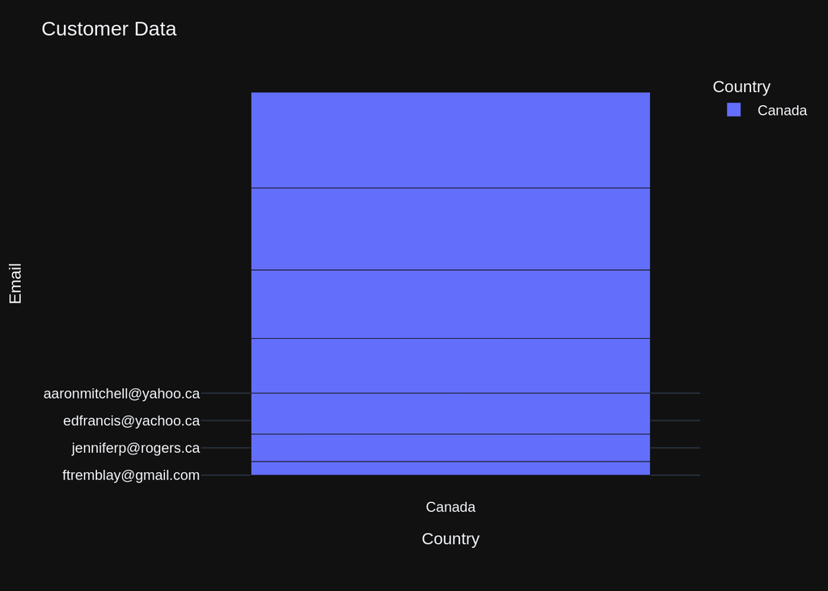

```
("SELECT c.Email, c.Country, c.CustomerId\nFROM Customer c\nWHERE c.Country = 'Canada'\n",
                     Email Country  CustomerId
 0     ftremblay@gmail.com  Canada           3
 1      mphilips12@shaw.ca  Canada          14
 2     jenniferp@rogers.ca  Canada          15
 3        robbrown@shaw.ca  Canada          29
 4     edfrancis@yachoo.ca  Canada          30
 5    marthasilk@gmail.com  Canada          31
 6  aaronmitchell@yahoo.ca  Canada          32
 7  ellie.sullivan@shaw.ca  Canada          33,
 Figure({
     'data': [{'alignmentgroup': 'True',
               'hovertemplate': 'Country=%{x}<br>Email=%{y}<extra></extra>',
               'legendgroup': 'Canada',
               'marker': {'color': '#636efa', 'pattern': {'shape': ''}},
               'name': 'Canada',
               'offsetgroup': 'Canada',
               'orientation': 'v',
               'showlegend': True,
               'textposition': 'auto',
               'type': 'bar',
               'x': array(['Canada', 'Canada', 'Canada', 'Canada', 'Canada', 'Canada', 'Canada',
                           'Canada'], dtype=object),
               'xaxis': 'x',
               'y': array(['ftremblay@gmail.com', 'mphilips12@shaw.ca', 'jenniferp@rogers.ca',
                           'robbrown@shaw.ca', 'edfrancis@yachoo.ca', 'marthasilk@gmail.com',
                           'aaronmitchell@yahoo.ca', 'ellie.sullivan@shaw.ca'], dtype=object),
               'yaxis': 'y'}],
     'layout': {'barmode': 'relative',
                'legend': {'title': {'text': 'Country'}, 'tracegroupgap': 0},
                'margin': {'t': 60},
                'template': '...',
                'title': {'text': 'Customer Data'},
                'xaxis': {'anchor': 'y',
                          'categoryarray': [Canada],
                          'categoryorder': 'array',
                          'domain': [0.0, 1.0],
                          'title': {'text': 'Country'}},
                'yaxis': {'anchor': 'x', 'domain': [0.0, 1.0], 'title': {'text': 'Email'}}}
 }))
```

```python
question = """
     List all customers from Canada and their email addresses:
"""

vn.ask(question=question)
```

```
Number of requested results 10 is greater than number of elements in index 1, updating n_results = 1
```

[output not shown]

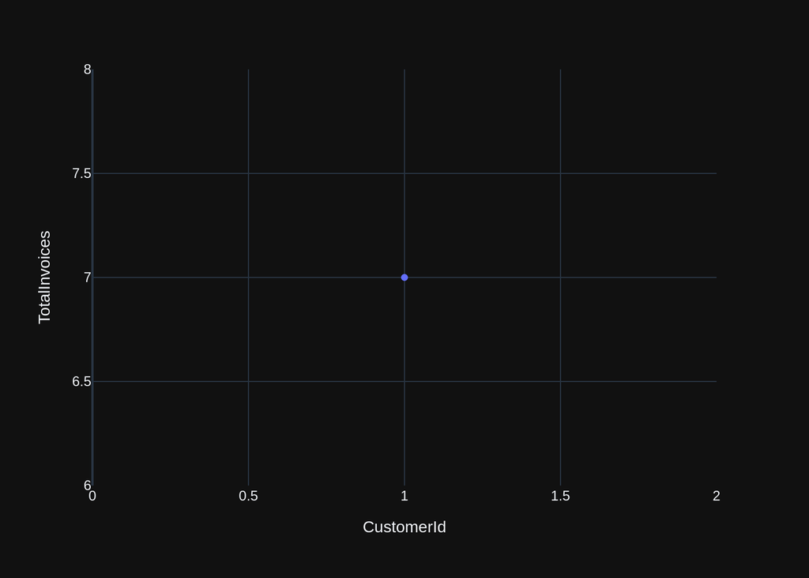

```
('SELECT c.CustomerId, COUNT(i.InvoiceId) AS TotalInvoices\nFROM Customer c\nJOIN Invoice i ON c.CustomerId = i.CustomerId\nGROUP BY c.CustomerId\nORDER BY TotalInvoices DESC\nLIMIT 1',
    CustomerId  TotalInvoices
 0           1              7,
 Figure({
     'data': [{'hovertemplate': 'CustomerId=%{x}<br>TotalInvoices=%{y}<extra></extra>',
               'legendgroup': '',
               'marker': {'color': '#636efa', 'symbol': 'circle'},
               'mode': 'markers',
               'name': '',
               'orientation': 'v',
               'showlegend': False,
               'type': 'scatter',
               'x': array([1]),
               'xaxis': 'x',
               'y': array([7]),
               'yaxis': 'y'}],
     'layout': {'legend': {'tracegroupgap': 0},
                'margin': {'t': 60},
                'template': '...',
                'xaxis': {'anchor': 'y', 'domain': [0.0, 1.0], 'title': {'text': 'CustomerId'}},
                'yaxis': {'anchor': 'x', 'domain': [0.0, 1.0], 'title': {'text': 'TotalInvoices'}}}
 }))
```

```python
question = """
     Find the customer with the most invoices
"""

vn.ask(question=question)
```

### Advanced SQL questions

```
Number of requested results 10 is greater than number of elements in index 1, updating n_results = 1
```

[output not shown]

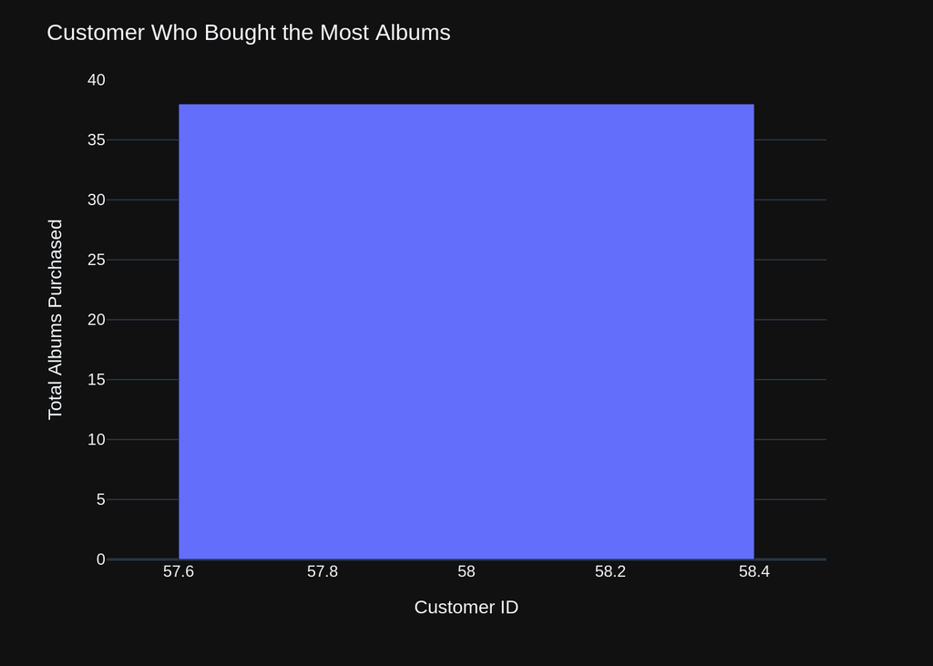

```
('SELECT c.CustomerId, SUM(il.Quantity) AS TotalAlbums\nFROM Customer c\nJOIN Invoice i ON c.CustomerId = i.CustomerId\nJOIN InvoiceLine il ON i.InvoiceId = il.InvoiceId\nGROUP BY c.CustomerId\nORDER BY TotalAlbums DESC\nLIMIT 1',
    CustomerId  TotalAlbums
 0          58           38,
 Figure({
     'data': [{'alignmentgroup': 'True',
               'hovertemplate': 'CustomerId=%{x}<br>TotalAlbums=%{y}<extra></extra>',
               'legendgroup': '',
               'marker': {'color': '#636efa', 'pattern': {'shape': ''}},
               'name': '',
               'offsetgroup': '',
               'orientation': 'v',
               'showlegend': False,
               'textposition': 'auto',
               'type': 'bar',
               'x': array([58]),
               'xaxis': 'x',
               'y': array([38]),
               'yaxis': 'y'}],
     'layout': {'barmode': 'relative',
                'legend': {'tracegroupgap': 0},
                'margin': {'t': 60},
                'template': '...',
                'title': {'text': 'Customer Who Bought the Most Albums'},
                'xaxis': {'anchor': 'y', 'domain': [0.0, 1.0], 'title': {'text': 'Customer ID'}},
                'yaxis': {'anchor': 'x', 'domain': [0.0, 1.0], 'title': {'text': 'Total Albums Purchased'}}}
 }))
```

```python
question = """
     Find the customer who bought the most albums in total quantity (across all invoices):
"""

vn.ask(question=question)
```

```python
question = """
     Find the top 5 customer who bought the most albums in total quantity (across all invoices):
"""

vn.ask(question=question)
```

```
Number of requested results 10 is greater than number of elements in index 1, updating n_results = 1
```

[output not shown]

```python
question = """
     Find the top 3 customers who spent the most money overall:
"""

vn.ask(question=question)
```

```
Number of requested results 10 is greater than number of elements in index 1, updating n_results = 1
```

[output not shown]

```
Number of requested results 10 is greater than number of elements in index 1, updating n_results = 1
```

[output not shown]

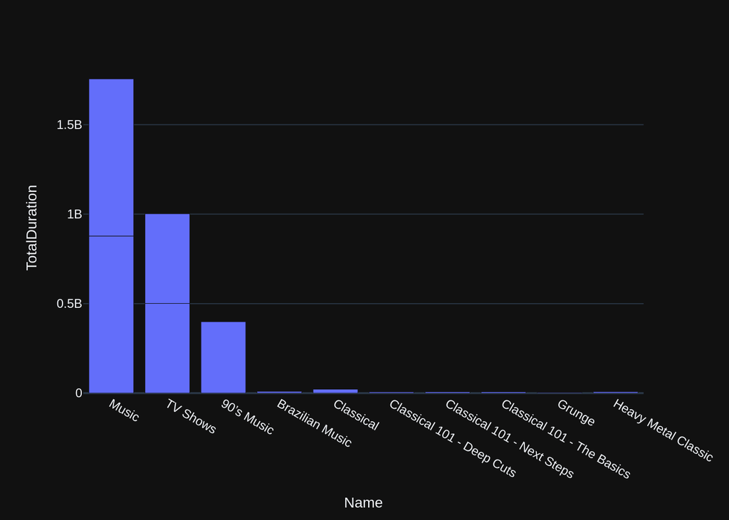

```
('SELECT p.PlaylistId, p.Name, SUM(t.Milliseconds) AS TotalDuration\nFROM Playlist p\nJOIN PlaylistTrack pt ON p.PlaylistId = pt.PlaylistId\nJOIN Track t ON pt.TrackId = t.TrackId\nGROUP BY p.PlaylistId, p.Name\nHAVING COUNT(pt.TrackId) >= 10',
     PlaylistId                        Name  TotalDuration
 0            1                       Music      877683083
 1            3                    TV Shows      501094957
 2            5                  90’s Music      398705153
 3            8                       Music      877683083
 4           10                    TV Shows      501094957
 5           11             Brazilian Music        9486559
 6           12                   Classical       21770592
 7           13   Classical 101 - Deep Cuts        6755730
 8           14  Classical 101 - Next Steps        7575051
 9           15  Classical 101 - The Basics        7439811
 10          16                      Grunge        4122018
 11          17         Heavy Metal Classic        8206312,
 Figure({
     'data': [{'alignmentgroup': 'True',
               'hovertemplate': 'Name=%{x}<br>TotalDuration=%{y}<extra></extra>',
               'legendgroup': '',
               'marker': {'color': '#636efa', 'pattern': {'shape': ''}},
               'name': '',
               'offsetgroup': '',
               'orientation': 'v',
               'showlegend': False,
               'textposition': 'auto',
               'type': 'bar',
               'x': array(['Music', 'TV Shows', '90’s Music', 'Music', 'TV Shows',
                           'Brazilian Music', 'Classical', 'Classical 101 - Deep Cuts',
                           'Classical 101 - Next Steps', 'Classical 101 - The Basics', 'Grunge',
                           'Heavy Metal Classic'], dtype=object),
               'xaxis': 'x',
               'y': array([877683083, 501094957, 398705153, 877683083, 501094957,   9486559,
                            21770592,   6755730,   7575051,   7439811,   4122018,   8206312]),
               'yaxis': 'y'}],
     'layout': {'barmode': 'relative',
                'legend': {'tracegroupgap': 0},
                'margin': {'t': 60},
                'template': '...',
                'xaxis': {'anchor': 'y', 'domain': [0.0, 1.0], 'title': {'text': 'Name'}},
                'yaxis': {'anchor': 'x', 'domain': [0.0, 1.0], 'title': {'text': 'TotalDuration'}}}
 }))
```

```python
question = """
     Get all playlists containing at least 10 tracks and the total duration of those tracks:
"""

vn.ask(question=question)
```

```python
question = """
     Identify artists who have albums with tracks appearing in multiple genres:
"""

vn.ask(question=question)
```

```
Number of requested results 10 is greater than number of elements in index 1, updating n_results = 1
```

[output not shown]

[output cut: 11 more lines]

[output not shown]

### Check completion time

```python
ts_stop = time()

elapsed_time = ts_stop - ts_start
print(f"elapsed_time : {elapsed_time} sec")
```

```
elapsed_time : 2600.9133360385895 sec
```

## Launch the User Interface

[figure not shown]

## Next Steps

Using Vanna via Jupyter notebooks is great for getting started but check out additional customizable interfaces like the

- [Streamlit app](https://github.com/vanna-ai/vanna-streamlit)
- [Flask app](https://github.com/vanna-ai/vanna-flask)
- [Slackbot](https://github.com/vanna-ai/vanna-slack)